# Job Application QJ45141

AH Uyekita

30 de setembro de 2018

# I. Introduction

This documents is an Aurora Energy Network evaluation based on data available in the Internet.

# II. Sinopsis

# III. Document Structure

The documents is very straigthforward, initialy I will describe all the Aurora Energy Network, and later I will compare with the other Lines Companies. I also will apply the K-means cluster method to compare in group.

# 1. General Information

## 1.1. Data Sources

All data of this analysis was downloaded in the internet.

- [Commerce Commission Website](https://comcom.govt.nz/regulated-industries/electricity-lines);
- [Aurora Energy Website](http://www.auroraenergy.co.nz/disclosures/)
- [Land Information New Zealand](https://data.linz.govt.nz/layer/51895-otago-075m-rural-aerial-photos-index-tiles-2004-2011/);
- [GeoJSON file](https://exploratory.io/map)

The most of the features on this document is also Open Source and free for use.

## 1.2. Softwares

To perform this stydies I adopt the R Language, which was created by [Ross Ihaka](https://en.wikipedia.org/wiki/Ross_Ihaka) and Robert Gentleman both professor of the University of Auckland. The IDE version and R used in this report were:

- R Version 3.5.1 ([Website](https://cran.r-project.org));
- RStudio Version 1.1.456 ([Website](https://www.rstudio.com)).

## 1.3. A briefly introduction about data

Unfornutaly, the dataset provided by ComCom is not a [*tidy dataset*](http://garrettgman.github.io/tidying/), and for this reason, I need to build a new version of data base.

# 2. Descriptive

[interactive chart not shown]

In recents news, Aurora Energy was investing to enhance the network since 2017, after a huge investment of 30 millions NZA. For this reason, this simple documents aims to find out which changes this investment bring to the company.

## 2.1. Distribution Network in Otago

The Otago’s state is divided geographically into two electrical distribution (macro-grids) according with the ComCom document. Although, the lack of information I assume each District compounded by these city:

- Dunedin (Clutha District, Dunedin City, and Waitaki District);
- Central Otago (Queenstown-Lakes District and CentralOtago District).

Based on it, the Table 1 represents the consumers of each Division.

| Year | Central Otago | Central Otago [%] | Dunedin | Dunedin [%] | Total |
| --- | --- | --- | --- | --- | --- |
| 2017 | 32943 | 37.31 | 55259 | 62.58 | 88305 |
| 2016 | 31876 | 36.69 | 54912 | 63.21 | 86870 |
| 2015 | 31119 | 36.24 | 54662 | 63.66 | 85863 |
| 2014 | 30795 | 36.01 | 54638 | 63.89 | 85515 |
| 2013 | 30237 | 35.63 | 54557 | 64.28 | 84875 |

The majority of consumer was located in Dunedin, about 62.58% which represent more than 55.000 consumer, and almost 33.000 consumer was settled in Central Otago. The trend in the last 5 year is the Central Otago increasing its participation on the total share, although Dunedin also increase its connnection number. The growth observed in these last 5 years was 4.04% in Otago Regional, but looking Central Otago separetaly its growth reach 8.95%. For this reason, the Central Otago could sature your power supply.

The next analysis will be performed based on these division. In this first analysis I will explore breafly all Assets of Aurora Energy::

- Network Length
  - Overhead
  - Underground
  - Street Lighting
  - Coastal or Geothermal
- Poles
  - Wood
  - Concrete or Stell
  - Aged Poles
- Transformers
- Capacitor Banks
- Voltage Regulator

### 2.1.1. Lines and Cables

By the *One Page Overview* downloaded at ComCom website, it is not possible to understand how is divided the grid. So, using the database from *Electricity distributors information disclosures 2013 March 2018* the length among these Network are showed in the Table 1a and Table 2b.

###### Table 1a

| Year | Central Otago | Central Otago [%] | Dunedin | Dunedin [%] | Total |
| --- | --- | --- | --- | --- | --- |
| 2017 | 3624.00 | 59.07 | 2511.00 | 40.93 | 6135.00 |
| 2016 | 3517.07 | 59.84 | 2353.18 | 40.04 | 5877.51 |
| 2015 | 3460.83 | 59.52 | 2346.59 | 40.36 | 5814.68 |
| 2014 | 3436.00 | 59.28 | 2516.00 | 43.41 | 5796.00 |
| 2013 | 3266.64 | 58.94 | 2268.72 | 40.93 | 5542.64 |

###### Table 1b

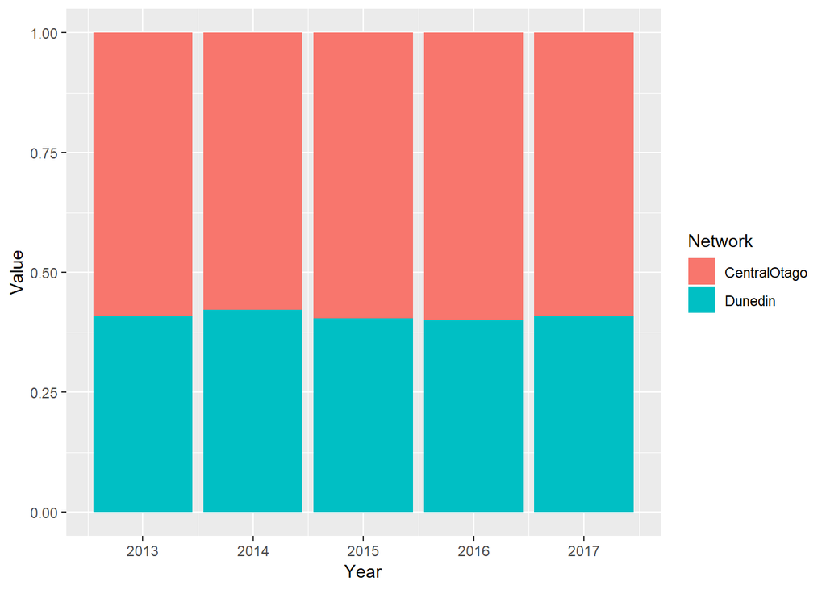

**Table 1b - Aurora Energy Network Composition in Percentage**

###### Graphic 1b

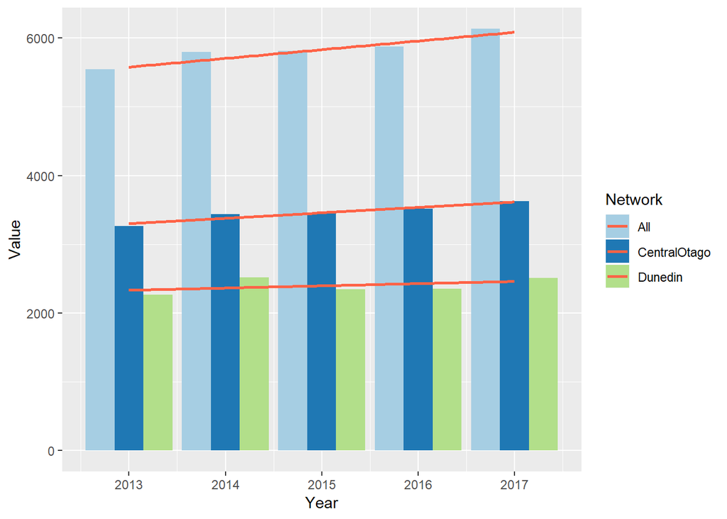

**Graphic 1b - Aurora Energy Network Composition**

### 2.1.2. Overhead and Underground lines

Segmentation of lines into Overhead and Underground

###### Table 1

| Year | Central Otago | Central Otago [%] | Dunedin | Dunedin [%] | Total |
| --- | --- | --- | --- | --- | --- |
| 2017 | 2186.00 | 55.57 | 1748.00 | 44.43 | 3934.00 |
| 2016 | 2182.97 | 56.12 | 1706.98 | 43.88 | 3889.95 |
| 2015 | 2183.00 | 56.12 | 1707.11 | 43.88 | 3890.11 |
| 2014 | 2190.00 | 56.14 | 1711.00 | 43.86 | 3901.00 |
| 2013 | 2189.88 | 56.19 | 1707.72 | 43.81 | 3897.60 |

###### Table 2

| Year | Central Otago | Central Otago [%] | Dunedin | Dunedin [%] | Total |
| --- | --- | --- | --- | --- | --- |
| 2017 | 1438.00 | 65.33 | 763.00 | 34.67 | 2201.00 |
| 2016 | 1334.10 | 67.12 | 646.20 | 32.51 | 1987.56 |
| 2015 | 1277.83 | 66.40 | 639.48 | 33.23 | 1924.57 |
| 2014 | 1246.00 | 65.75 | 805.00 | 42.48 | 1895.00 |
| 2013 | 1076.76 | 65.45 | 561.00 | 34.10 | 1645.04 |

###### Table 3

[figure not shown]

### 2.1.2. Street Lighting

Aurora Energy provide the service of Public Illumination in Otago Region Council. The results found was Dunedin with double of street lighting network than CentralOtago as showed in the Graphic 2, Table 2a, and table 2b.

###### Graphic

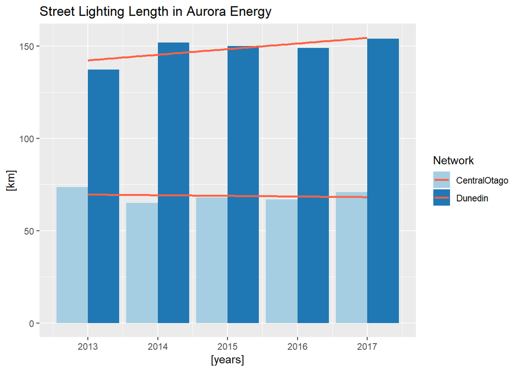

**Street Lighting Comparison**

###### Table 2a

| Year | Central Otago | Central Otago [%] | Dunedin | Dunedin [%] | Total |
| --- | --- | --- | --- | --- | --- |
| 2017 | 71.00 | 32.13 | 154.00 | 69.68 | 221.00 |
| 2016 | 67.00 | 30.88 | 149.00 | 68.66 | 217.00 |
| 2015 | 68.00 | 31.05 | 150.00 | 68.49 | 219.00 |
| 2014 | 65.00 | 29.82 | 152.00 | 69.72 | 218.00 |
| 2013 | 73.71 | 34.73 | 137.28 | 64.69 | 212.22 |

**Table 2 - Total Street Lighting in each Network**

###### Table 2b

| Year | Central Otago Street [km] | Central Otago Subtotal [km] | Central Otago [%] | Dunedin Street [km] | Dunedin Subtotal [km] | Dunedin [%] | Total Street [km] | Total Total Network [km] | Total % |
| --- | --- | --- | --- | --- | --- | --- | --- | --- | --- |
| 2017 | 71.00 | 3624.00 | 1.96 | 154.00 | 2511.00 | 6.13 | 221.00 | 6135.00 | 3.60 |
| 2016 | 67.00 | 3517.07 | 1.90 | 149.00 | 2353.18 | 6.33 | 217.00 | 5877.51 | 3.69 |
| 2015 | 68.00 | 3460.83 | 1.96 | 150.00 | 2346.59 | 6.39 | 219.00 | 5814.68 | 3.77 |
| 2014 | 65.00 | 3436.00 | 1.89 | 152.00 | 2516.00 | 6.04 | 218.00 | 5796.00 | 3.76 |
| 2013 | 73.71 | 3266.64 | 2.26 | 137.28 | 2268.72 | 6.05 | 212.22 | 5542.64 | 3.83 |

**Total Street Lighting in each Network**

### 2.1.3. Tree Management in Overhead lines

This section show the Network length under Tree Management.

###### Graphic 3a

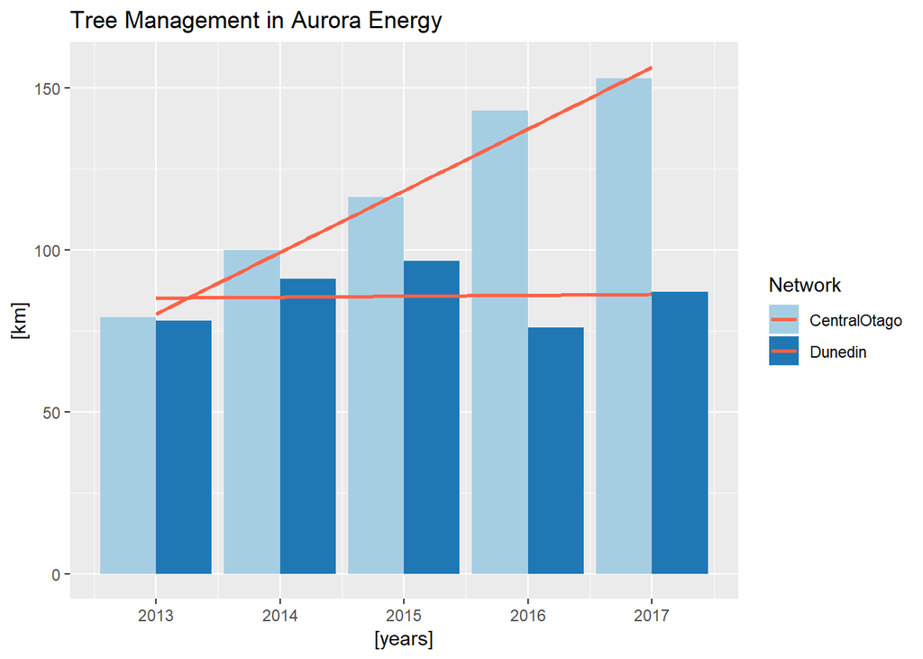

###### Table 3a

| Year | Central Otago | Central Otago [%] | Dunedin | Dunedin [%] | Total |
| --- | --- | --- | --- | --- | --- |
| 2017 | 153.00 | 63.75 | 87.00 | 36.25 | 240.00 |
| 2016 | 143.00 | 65.30 | 76.00 | 34.70 | 219.00 |
| 2015 | 116.28 | 54.65 | 96.48 | 45.35 | 212.76 |
| 2014 | 100.00 | 52.36 | 91.00 | 47.64 | 191.00 |
| 2013 | 79.22 | 50.36 | 78.07 | 49.64 | 157.29 |

###### Obs.:

It was necessary perform two searches:

- 2013 and 2014: Section -> 9c: Overhead lines and underground cables, Categgory -> Total overhead length, Sub-category -> Circuit length (km), Description -> Overhead circuit requiring vegetation management
- 2015, 2016 and 2017: Section -> Overhead lines and underground cables, Category -> Overhead circuit requiring vegetation management, Subcategoryv -> “Circuit length (km)

The length of Tree Management in Dunedin kept almost steadly comparing with Central Otago, which has increased 93.13% in 5 years.

### 2.1.4. Coastal and Geothermal within 10 km

As expected the Central Otago do not have areas affected by the ocean, and also do not have any kilometre in geothermal areas as the number can proof. All length are concentrated in Dunedin Network where is the most populated costal of this Region.

###### Graphic

| Year | Central Otago | Central Otago [%] | Dunedin | Dunedin [%] | Total |
| --- | --- | --- | --- | --- | --- |
| 2017 | 0 | 0 | 2266.00 | 100 | 2266.00 |
| 2016 | 0 | 0 | 2132.27 | 100 | 2132.27 |
| 2015 | 0 | 0 | 2125.08 | 100 | 2125.08 |
| 2014 | NA | NA | 2131.00 | 100 | 2131.00 |
| 2013 | 0 | 0 | 1947.88 | 100 | 1947.88 |

###### Graphic

[figure not shown]

As I expected, there are only lines affected by the ocean salt and by the geothermal activities in the Dunedin Network. These length are increase possibly due to the network expansion. In Brazil, the coastal lines were different from the regular basis, due to the corrosive effect from the salt. There many incidents of electrical discharge the excess of salt on the 13,8 kV pillar isolator, to mitigate this incident they adopt a water jet to wash each isolator for prevent.

### 2.1.6. LV Length Lines and Cables

The LV Lines kept steadly around 5 years with a share of `21,5%` in Central Otago and `78,5%` in Dunedin.

| Year | Central Otago | Central Otago [%] | Dunedin | Dunedin [%] | Total |
| --- | --- | --- | --- | --- | --- |
| 2017 | 225.0 | 21.43 | 824.00 | 78.48 | 1050.00 |
| 2016 | 226.0 | 21.52 | 824.00 | 78.48 | 1050.00 |
| 2015 | 226.0 | 21.50 | 825.00 | 78.50 | 1051.00 |
| 2014 | 226.0 | 21.48 | 826.00 | 78.52 | 1052.00 |
| 2013 | 226.4 | 21.57 | 823.22 | 78.43 | 1049.61 |

### 2.1.7. HV Lines Length and Cables

The HV Lines also kept steadly around 5 years with a share of `68,0%` in Central Otago and `32,0%` in Dunedin.

| Year | Central Otago | Central Otago [%] | Dunedin | Dunedin [%] | Total |
| --- | --- | --- | --- | --- | --- |
| 2017 | 1576.00 | 68.02 | 740.00 | 31.94 | 2317.00 |
| 2016 | 1577.00 | 68.06 | 740.00 | 31.94 | 2317.00 |
| 2015 | 1593.00 | 68.31 | 739.00 | 31.69 | 2332.00 |
| 2014 | 1595.00 | 68.28 | 741.00 | 31.72 | 2336.00 |
| 2013 | 1595.67 | 68.26 | 742.01 | 31.74 | 2337.69 |

### 2.1.8. HV Lines Length Subtransmission

| Year | Central Otago | Central Otago [%] | Dunedin | Dunedin [%] | Total |
| --- | --- | --- | --- | --- | --- |
| 2017 | 0 | NaN | 0 | NaN | 0 |
| 2016 | 0 | NaN | 0 | NaN | 0 |
| 2015 | 0 | NaN | 0 | NaN | 0 |
| 2014 | 0 | NaN | 0 | NaN | 0 |
| 2013 | 0 | NaN | 0 | NaN | 0 |

### 2.2.2. Rural Overhead Lines

Almost 74% of Rural Overhead lines in Otago Regional were in Central Otago and 26% in Dunedin.

###### Table

| Year | Central Otago | Central Otago [%] | Dunedin | Dunedin [%] | Total |
| --- | --- | --- | --- | --- | --- |
| 2017 | 1860.00 | 73.78 | 662.00 | 26.26 | 2521.00 |
| 2016 | 1894.68 | 72.44 | 720.76 | 27.56 | 2615.44 |
| 2015 | 1894.68 | 72.44 | 720.76 | 27.56 | 2615.44 |
| 2014 | 1913.00 | 72.22 | 736.00 | 27.78 | 2649.00 |
| 2013 | 1817.92 | 77.98 | 513.40 | 22.02 | 2331.32 |

###### Table

| Year | Central Otago Rural [km] | Central Otago Overhead [km] | Central Otago [%] | Dunedin Rural [km] | Dunedin Overhead [km] | Dunedin [%] | Otago Regional Rural [km] | Otago Regional Total Overhead [km] | Otago Regional [%] |
| --- | --- | --- | --- | --- | --- | --- | --- | --- | --- |
| 2017 | 1860.00 | 2186.00 | 85.09 | 662.00 | 1748.00 | 37.87 | 2521.00 | 3934.00 | 64.08 |
| 2016 | 1894.68 | 2182.97 | 86.79 | 720.76 | 1706.98 | 42.22 | 2615.44 | 3889.95 | 67.24 |
| 2015 | 1894.68 | 2183.00 | 86.79 | 720.76 | 1707.11 | 42.22 | 2615.44 | 3890.11 | 67.23 |
| 2014 | 1913.00 | 2190.00 | 87.35 | 736.00 | 1711.00 | 43.02 | 2649.00 | 3901.00 | 67.91 |
| 2013 | 1817.92 | 2189.88 | 83.01 | 513.40 | 1707.72 | 30.06 | 2331.32 | 3897.60 | 59.81 |

More than 85% of the network in CentralOtago was in Rural Area.

More than 37% of the Dunedin was in Rural Area.

### 2.2.3. Urban Overhead Lines

###### Table

| Year | Central Otago | Central Otago [%] | Dunedin | Dunedin [%] | Total |
| --- | --- | --- | --- | --- | --- |
| 2017 | 238.00 | 18.15 | 1072.00 | 81.77 | 1311.00 |
| 2016 | 199.02 | 16.98 | 972.81 | 83.02 | 1171.83 |
| 2015 | 199.02 | 16.98 | 972.81 | 83.02 | 1171.83 |
| 2014 | 187.00 | 16.29 | 961.00 | 83.71 | 1148.00 |
| 2013 | 281.86 | 19.27 | 1180.80 | 80.73 | 1462.65 |

###### Table

| Year | Central Otago Urban [km] | Central Otago Overhead [km] | Central Otago [%] | Dunedin Urban [km] | Dunedin Overhead [km] | Dunedin [%] | Otago Regional Urban [km] | Otago Regional Total Overhead [km] | Otago Regional [%] |
| --- | --- | --- | --- | --- | --- | --- | --- | --- | --- |
| 2017 | 238.00 | 2186.00 | 10.89 | 1072.00 | 1748.00 | 61.33 | 1311.00 | 3934.00 | 33.32 |
| 2016 | 199.02 | 2182.97 | 9.12 | 972.81 | 1706.98 | 56.99 | 1171.83 | 3889.95 | 30.12 |
| 2015 | 199.02 | 2183.00 | 9.12 | 972.81 | 1707.11 | 56.99 | 1171.83 | 3890.11 | 30.12 |
| 2014 | 187.00 | 2190.00 | 8.54 | 961.00 | 1711.00 | 56.17 | 1148.00 | 3901.00 | 29.43 |
| 2013 | 281.86 | 2189.88 | 12.87 | 1180.80 | 1707.72 | 69.14 | 1462.65 | 3897.60 | 37.53 |

### 2.2.4. Rugged Overhead Lines

###### Table

| Year | Central Otago | Central Otago [%] | Dunedin | Dunedin [%] | Total |
| --- | --- | --- | --- | --- | --- |
| 2017 | 88.00 | 86.27 | 14.00 | 13.73 | 102.00 |
| 2016 | 89.27 | 86.94 | 13.41 | 13.06 | 102.68 |
| 2015 | 89.30 | 86.83 | 13.54 | 13.17 | 102.84 |
| 2014 | 90.00 | 86.54 | 14.00 | 13.46 | 104.00 |
| 2013 | 90.10 | 86.95 | 13.53 | 13.05 | 103.63 |

###### Table

| Year | Central Otago Urban [km] | Central Otago Overhead [km] | Central Otago [%] | Dunedin Urban [km] | Dunedin Overhead [km] | Dunedin [%] | Otago Regional Urban [km] | Otago Regional Total Overhead [km] | Otago Regional [%] |
| --- | --- | --- | --- | --- | --- | --- | --- | --- | --- |
| 2017 | 88.00 | 2186.00 | 4.03 | 14.00 | 1748.00 | 0.80 | 102.00 | 3934.00 | 2.59 |
| 2016 | 89.27 | 2182.97 | 4.09 | 13.41 | 1706.98 | 0.79 | 102.68 | 3889.95 | 2.64 |
| 2015 | 89.30 | 2183.00 | 4.09 | 13.54 | 1707.11 | 0.79 | 102.84 | 3890.11 | 2.64 |
| 2014 | 90.00 | 2190.00 | 4.11 | 14.00 | 1711.00 | 0.82 | 104.00 | 3901.00 | 2.67 |
| 2013 | 90.10 | 2189.88 | 4.11 | 13.53 | 1707.72 | 0.79 | 103.63 | 3897.60 | 2.66 |